# Course Project 1

16/02/2021

# Background

Using devices such as Jawbone Up, Nike FuelBand, and Fitbit it is now possible to collect a large amount of data about personal activity relatively inexpensively. These type of devices are part of the quantified self movement – a group of enthusiasts who take measurements about themselves regularly to improve their health, to find patterns in their behavior, or because they are tech geeks. One thing that people regularly do is quantify how much of a particular activity they do, but they rarely quantify how well they do it. In this project, your goal will be to use data from accelerometers on the belt, forearm, arm, and dumbell of 6 participants. They were asked to perform barbell lifts correctly and incorrectly in 5 different ways. More information is available from the website here: http://groupware.les.inf.puc-rio.br/har (see the section on the Weight Lifting Exercise Dataset).

# Project Goal

The goal of your project is to predict the manner in which they did the exercise. This is the “classe” variable in the training set. You may use any of the other variables to predict with. You should create a report describing how you built your model, how you used cross validation, what you think the expected out of sample error is, and why you made the choices you did. You will also use your prediction model to predict 20 different test cases.

## Load the Relevant Libaries

```r
library(caret)
```

```r
library(rpart)
library(rpart.plot)
library(rattle)
library(randomForest)
library(corrplot)
```

# Loading the Data and Analysis

## Loading the data

If the files don’t already exist then we download them.

```r
if (!file.exists("pml-training.csv")) {

    file_url <- "https://d396qusza40orc.cloudfront.net/predmachlearn/pml-training.csv"
    file_name <- "pml-training.csv"
    download.file(file_url, file_name, method = "curl")
}

if (!file.exists("pml-testing.csv")) {

    file_url <- "https://d396qusza40orc.cloudfront.net/predmachlearn/pml-testing.csv"
    file_name <- "pml-testing.csv"
    download.file(file_url, file_name, method = "curl")
}

training = read.csv("pml-training.csv")
testing = read.csv("pml-testing.csv")
```

## Data Visualisation

```r
str(training)
```

```
## 'data.frame':    19622 obs. of  160 variables:
##  $ X                       : int  1 2 3 4 5 6 7 8 9 10 ...
##  $ user_name               : chr  "carlitos" "carlitos" "carlitos" "carlitos" ...
##  $ raw_timestamp_part_1    : int  1323084231 1323084231 1323084231 1323084232 1323084232 1323084232 1323084232 1323084232 1323084232 1323084232 ...
##  $ raw_timestamp_part_2    : int  788290 808298 820366 120339 196328 304277 368296 440390 484323 484434 ...
##  $ cvtd_timestamp          : chr  "05/12/2011 11:23" "05/12/2011 11:23" "05/12/2011 11:23" "05/12/2011 11:23" ...
##  $ new_window              : chr  "no" "no" "no" "no" ...
##  $ num_window              : int  11 11 11 12 12 12 12 12 12 12 ...
##  $ roll_belt               : num  1.41 1.41 1.42 1.48 1.48 1.45 1.42 1.42 1.43 1.45 ...
##  $ pitch_belt              : num  8.07 8.07 8.07 8.05 8.07 8.06 8.09 8.13 8.16 8.17 ...
##  $ yaw_belt                : num  -94.4 -94.4 -94.4 -94.4 -94.4 -94.4 -94.4 -94.4 -94.4 -94.4 ...
##  $ total_accel_belt        : int  3 3 3 3 3 3 3 3 3 3 ...
##  $ kurtosis_roll_belt      : chr  "" "" "" "" ...
##  $ kurtosis_picth_belt     : chr  "" "" "" "" ...
##  $ kurtosis_yaw_belt       : chr  "" "" "" "" ...
```

[output cut: 86 more lines]

## Data Cleaning

The training dataset is split to create a “Training” set (80%) and a “Test” set (20%), to perform validations.

```r
set.seed("2021")

inTrain <- createDataPartition(training$classe, p=0.8, list=FALSE)

TrainingSet <- training[inTrain,]
TestingSet <- training[-inTrain,]

#Checking the dimensions of both sets
rbind(dim(TrainingSet), dim(TestingSet))
```

```
##       [,1] [,2]
## [1,] 15699  160
## [2,]  3923  160
```

It can be see that there are 160 features in our Training Set and our Testing Set. We can look at reducing the amount of features.

First lets remove the ’identification` features in the first 5 columns as they do not provide any assistance.

```r
TrainingSet <- TrainingSet[, -(1:5)]
TestingSet <- TestingSet[, -(1:5)]
```

Now, by using the nearZeroVar function, we can remove features that have very little change or variation, meaning that they are not useful for prediction.

```r
nearZero = nearZeroVar(TrainingSet)

TrainingSet <- TrainingSet[, -nearZero]
TestingSet <- TestingSet[, -nearZero]

#Checking the dimensions of both sets
rbind(dim(TrainingSet), dim(TestingSet))
```

```
##       [,1] [,2]
## [1,] 15699   97
## [2,]  3923   97
```

We now have 97 features in both the Training and Testing set.

Lets see how many NA values we have in total:

```r
sum(is.na(TrainingSet)) + sum(is.na(TestingSet))
```

```
## [1] 826288
```

We have ALOT of NA values. It would be beneficial to check for any features that contain mostly NA values (85% or more) and then remove them.

```r
#NACol Produces a Logical list
NACol <- sapply(TrainingSet, function(x) mean(is.na(x))) > 0.85

TrainingSet <- TrainingSet[, NACol == FALSE]
TestingSet <- TestingSet[, NACol == FALSE]

#Checking the dimensions of both sets
rbind(dim(TrainingSet), dim(TestingSet))
```

```
##       [,1] [,2]
## [1,] 15699   54
## [2,]  3923   54
```

## Correlation

Lets take a look at the correlation between features using a corrplot.

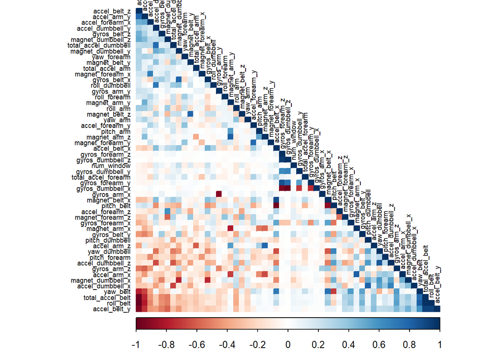

```r
corMatrix <- cor(TrainingSet[, -54])

corrplot(corMatrix, order='FPC', method = 'color', type='lower', tl.cex=0.55, tl.col=rgb(0,0,0))
```

# Building a Model

We will look and try 3 different types of models. A Generalised Boosted Model, Decisions Trees and Random Forest.

## Generalised Boosted Model

```r
#5 Fold Cross Validation
GBM_Control <- trainControl(method = "repeatedcv", number = 5, repeats = 1)

GBM_Fit <- train(classe ~., data = TrainingSet,
                 method = "gbm", trControl = GBM_Control,
                 verbose = FALSE)

#Predict on the Testing set
GBM_Predict <- predict(GBM_Fit, newdata = TestingSet)

#Produce a Confusion Matrix
GBM_confMat <- confusionMatrix(GBM_Predict, as.factor(TestingSet$classe))
GBM_confMat
```

```
## Confusion Matrix and Statistics
##
##           Reference
## Prediction    A    B    C    D    E
##          A 1115    4    0    1    0
##          B    0  746    7    7    4
##          C    0    9  675    8    2
##          D    1    0    2  626   11
##          E    0    0    0    1  704
##
## Overall Statistics
##
##                Accuracy : 0.9855
##                  95% CI : (0.9812, 0.989)
##     No Information Rate : 0.2845
##     P-Value [Acc > NIR] : < 2.2e-16
##
##                   Kappa : 0.9816
##
##  Mcnemar's Test P-Value : NA
##
## Statistics by Class:
##
##                      Class: A Class: B Class: C Class: D Class: E
## Sensitivity            0.9991   0.9829   0.9868   0.9736   0.9764
## Specificity            0.9982   0.9943   0.9941   0.9957   0.9997
## Pos Pred Value         0.9955   0.9764   0.9726   0.9781   0.9986
## Neg Pred Value         0.9996   0.9959   0.9972   0.9948   0.9947
## Prevalence             0.2845   0.1935   0.1744   0.1639   0.1838
## Detection Rate         0.2842   0.1902   0.1721   0.1596   0.1795
## Detection Prevalence   0.2855   0.1947   0.1769   0.1631   0.1797
## Balanced Accuracy      0.9987   0.9886   0.9905   0.9846   0.9881
```

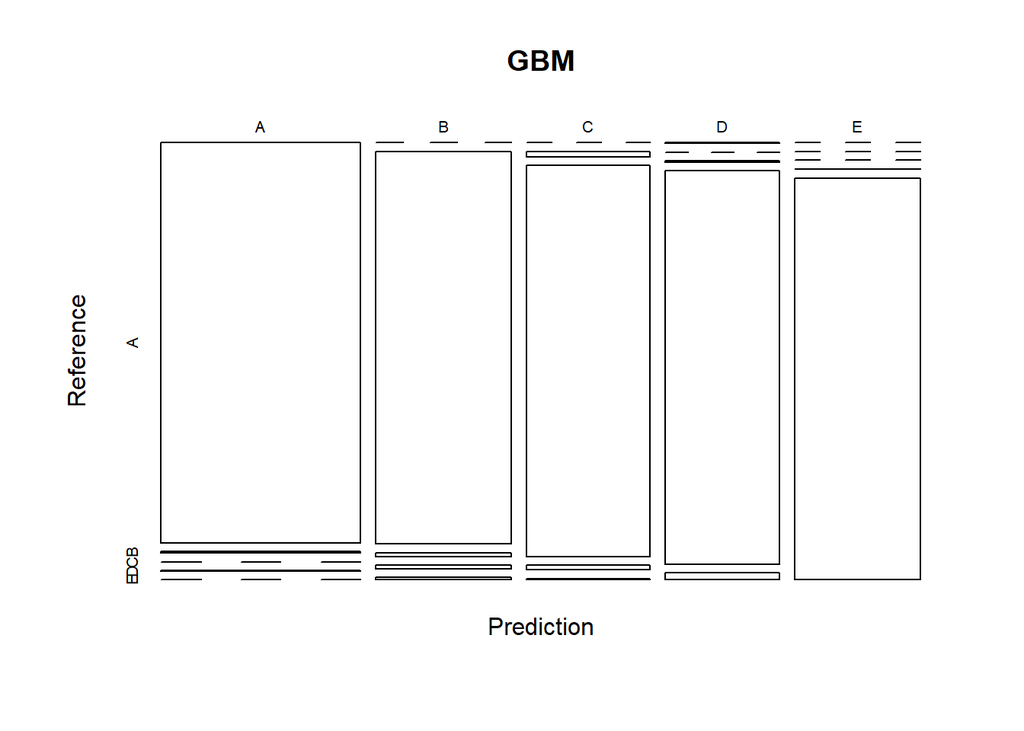

```r
#Visual Plot of Predictions
plot(GBM_confMat$table, col = GBM_confMat$byClass, main = "GBM")
```

```r
#Print the accuracy
paste('Accuracy of:', round(GBM_confMat$overall['Accuracy'], 4))
```

```
## [1] "Accuracy of: 0.9855"
```

## Decision Trees

[figure not shown]

```r
Decision_Fit <- rpart(classe ~., data = TrainingSet, method = 'class')

fancyRpartPlot(Decision_Fit)
```

```r
Decision_Predict <- predict(Decision_Fit, newdata = TestingSet, type = 'class')

Decision_confMat <- confusionMatrix(Decision_Predict, as.factor(TestingSet$classe))
Decision_confMat
```

```
## Confusion Matrix and Statistics
##
##           Reference
## Prediction   A   B   C   D   E
##          A 993 136  44  54  52
##          B  39 437  27  43  67
##          C   6  49 532 100  49
##          D  64  97  35 405  89
##          E  14  40  46  41 464
##
## Overall Statistics
##
##                Accuracy : 0.7216
##                  95% CI : (0.7073, 0.7356)
##     No Information Rate : 0.2845
##     P-Value [Acc > NIR] : < 2.2e-16
##
##                   Kappa : 0.6464
##
##  Mcnemar's Test P-Value : < 2.2e-16
##
## Statistics by Class:
##
##                      Class: A Class: B Class: C Class: D Class: E
## Sensitivity            0.8898   0.5758   0.7778   0.6299   0.6436
## Specificity            0.8981   0.9444   0.9370   0.9131   0.9560
## Pos Pred Value         0.7764   0.7129   0.7228   0.5870   0.7669
## Neg Pred Value         0.9535   0.9027   0.9523   0.9264   0.9225
## Prevalence             0.2845   0.1935   0.1744   0.1639   0.1838
## Detection Rate         0.2531   0.1114   0.1356   0.1032   0.1183
## Detection Prevalence   0.3260   0.1563   0.1876   0.1759   0.1542
## Balanced Accuracy      0.8939   0.7601   0.8574   0.7715   0.7998
```

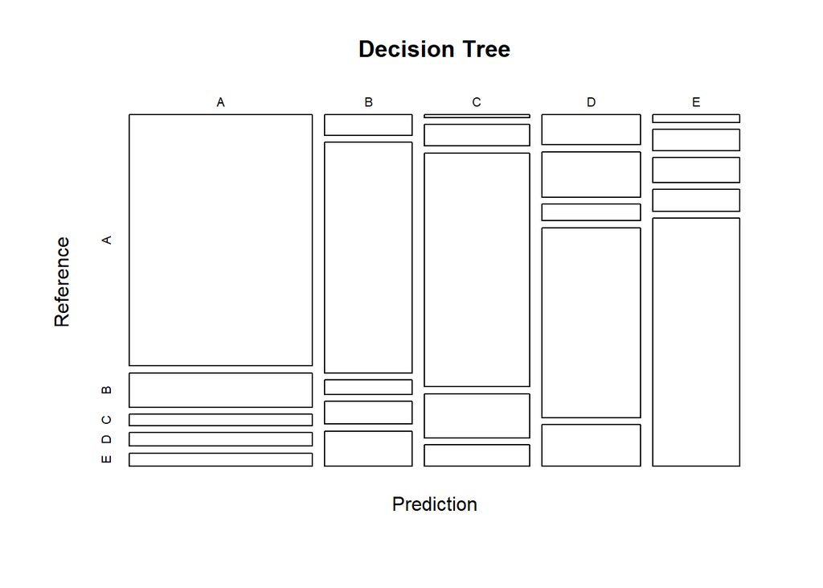

```r
plot(Decision_confMat$table, col = Decision_confMat$byClass, main = "Decision Tree")
```

```r
#Print the accuracy
paste('Accuracy of:', round(Decision_confMat$overall['Accuracy'], 4))
```

```
## [1] "Accuracy of: 0.7216"
```

## Random Forest

```r
Forest_Control <- trainControl(method="cv", number=3, verboseIter=FALSE)

Forest_Fit <- train(classe ~ ., method="rf", data=TrainingSet, trControl=Forest_Control,
                    verbose=FALSE)

#Predict on the Testing set
Forest_Predict <- predict(Forest_Fit, newdata = TestingSet)

#Produce a Confusion Matrix
Forest_confMat <- confusionMatrix(Forest_Predict, as.factor(TestingSet$classe))
Forest_confMat
```

```
## Confusion Matrix and Statistics
##
##           Reference
## Prediction    A    B    C    D    E
##          A 1116    3    0    0    0
##          B    0  755    0    0    0
##          C    0    0  684    1    0
##          D    0    1    0  642    1
##          E    0    0    0    0  720
##
## Overall Statistics
##
##                Accuracy : 0.9985
##                  95% CI : (0.9967, 0.9994)
##     No Information Rate : 0.2845
##     P-Value [Acc > NIR] : < 2.2e-16
##
##                   Kappa : 0.9981
##
##  Mcnemar's Test P-Value : NA
##
## Statistics by Class:
##
##                      Class: A Class: B Class: C Class: D Class: E
## Sensitivity            1.0000   0.9947   1.0000   0.9984   0.9986
## Specificity            0.9989   1.0000   0.9997   0.9994   1.0000
## Pos Pred Value         0.9973   1.0000   0.9985   0.9969   1.0000
## Neg Pred Value         1.0000   0.9987   1.0000   0.9997   0.9997
## Prevalence             0.2845   0.1935   0.1744   0.1639   0.1838
## Detection Rate         0.2845   0.1925   0.1744   0.1637   0.1835
## Detection Prevalence   0.2852   0.1925   0.1746   0.1642   0.1835
## Balanced Accuracy      0.9995   0.9974   0.9998   0.9989   0.9993
```

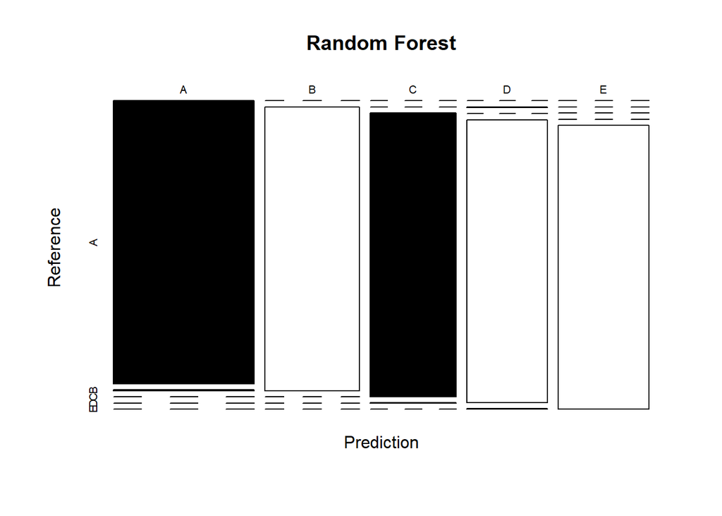

```r
#Visual Plot of Predictions
plot(Forest_confMat$table, col = Forest_confMat$byClass, main = "Random Forest")
```

```r
#Print the accuracy
paste('Accuracy of:', round(Forest_confMat$overall['Accuracy'], 4))
```

```
## [1] "Accuracy of: 0.9985"
```

# Using the Best Model on the Test Data

Random Forest provided the best accuracy with a score of `0.9985`.

Using the random forest model on the test data we get:

```r
Forest_Predict_Test <- predict(Forest_Fit, newdata = testing)
Forest_Predict_Test
```

```
##  [1] B A B A A E D B A A B C B A E E A B B B
## Levels: A B C D E
```